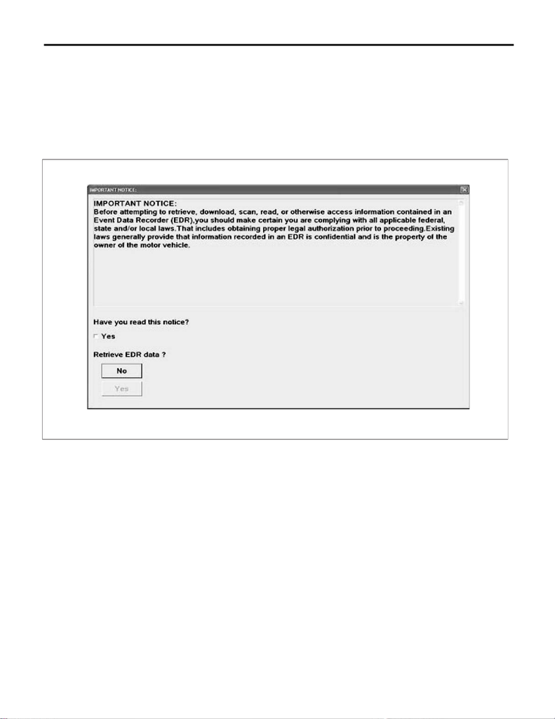

Event Record Data

AIRBAG SYSTEM (DIAGNOSTICS)

12.Event Record Data

A: OPERATION

1) On «Main Menu» display, select {Each System Check}.

2) On «System Selection Menu» display, select {Airbag System}.

4) After checking the content of «IMPORTANT NOTICE», click the checkbox for “Yes”.

5) If the applicable law is not violated, click the [Yes] button to display the EDR data.

6) Select the items to be checked from each event record data.

7) Select the record data to be checked from each record data.

9) Select [Exit] to return to each event record data screen.